# Tugas PRaktikum 5

```r
library(ggplot2)
library(tsibble)
library(tseries)
library(MASS)
library(TSA)
library(lmtest)
set.seed(1945)
```

# SOAL 1

## BANGKITKAN DATA (MA(2), n=300, teta1=0.4, teta2=0.6)

```r
datama2 <- arima.sim(n=300, list(order=c(0,0,2), ma=c(0.4, 0.6)))
```

## Plot *Time Series*

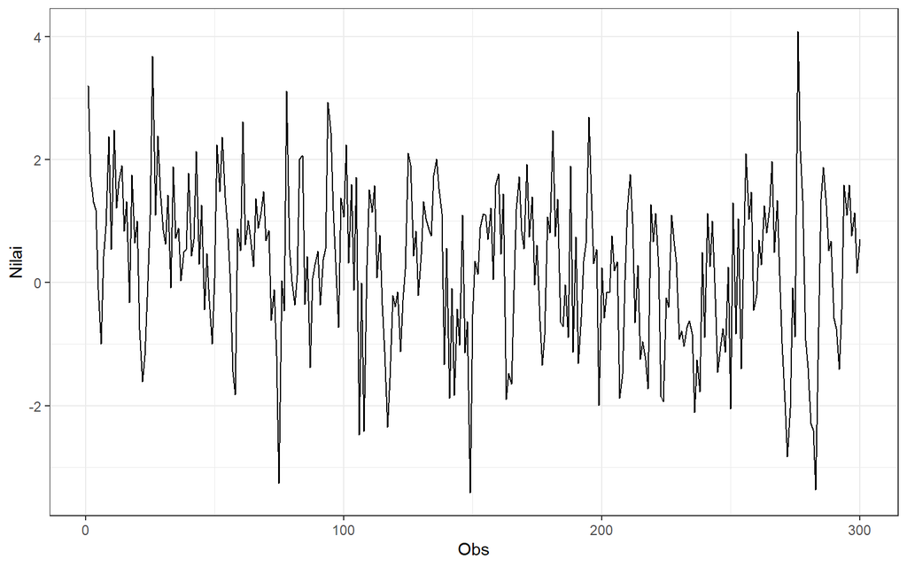

```r
plot_datama2 <- datama2 |> as_tsibble() |>
  ggplot(aes(x = index, y = value)) + geom_line() + theme_bw() +
  xlab("Obs") + ylab("Nilai")
plot_datama2
```

```r
mean(datama2)
```

```
## [1] 0.2882689
```

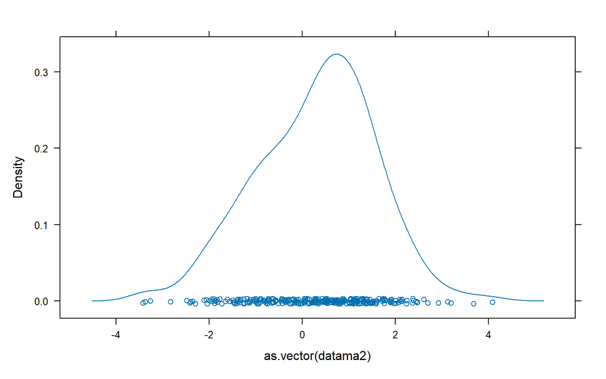

```r
lattice::densityplot(as.vector(datama2))
```

Plot deret waktu di atas menunjukkan bahwa data stasioner dalam rataan, ditandai dengan data yang menyebar di sekitar nilai tengahnya (0) dan stasioner dalam ragam, ditandai dengan data berfluktuasi pada rentang yang relatif sama sepanjang waktu.

## Plot ACF

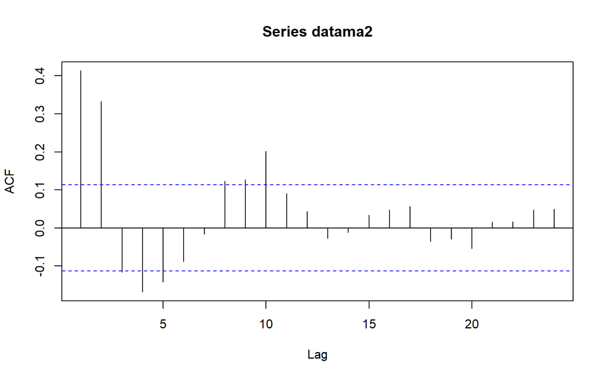

```r
acf(datama2)
```

Berdasarkan plot ACF, terlihat bahwa plot ACF pada data tersebut cenderung *tails off* dan membentuk gelombang sinus.

## Plot PACF

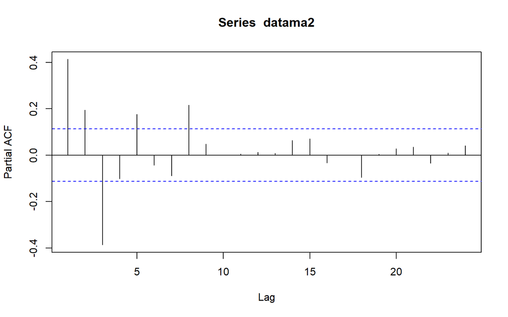

```r
pacf(datama2)
```

Berdasarkan plot PACF, terlihat bahwa plot PCF pada data tersebut cenderung *tails off* dan membentuk gelombang sinus.

## Plot EACF

```r
eacf(datama2)
```

```
## AR/MA
##   0 1 2 3 4 5 6 7 8 9 10 11 12 13
## 0 x x x x x o o x x x o  o  o  o
## 1 x x x o o o o o o x o  o  o  o
## 2 x x x o o o o o o x o  o  o  o
## 3 x x x o o o o o o x o  o  o  o
## 4 x x x o o x o o o x o  o  o  o
## 5 x x o x x x o o o o o  o  o  o
## 6 x x x o x x o o o o o  o  o  o
## 7 x x x o x x x o x o o  o  o  o
```

## Uji ADF

Uji ADF (Augmented Dickey–Fuller) adalah uji statistik yang digunakan untuk memeriksa apakah suatu deret waktu stasioner dalam rataan.

```r
tseries::adf.test(datama2)
```

```
##
##  Augmented Dickey-Fuller Test
##
## data:  datama2
## Dickey-Fuller = -8.0967, Lag order = 6, p-value = 0.01
## alternative hypothesis: stationary
```

$H_0$ : Data tidak stasioner dalam rataan

$H_1$ : Data stasioner dalam rataan

Berdasarkan uji ADF tersebut, didapat *p-value* sebesar 0.01 yang lebih kecil dari taraf nyata 5% sehingga tolak $H_0$ dan menandakan bahwa data **stasioner dalam rataan**. Hal ini sesuai dengan hasil eksplorasi menggunakan plot time series dan plot ACF, dan PACF.

## Scatter Plot

```r
data_lag <- data.frame(
  Yt = datama2,
  Lag1 = c(NA, datama2[-length(datama2)]),
  Lag2 = c(NA, NA, datama2[-c(length(datama2)-1, length(datama2))]),
  Lag3 = c(NA, NA, NA, datama2[-c(length(datama2)-2, length(datama2)-1, length(datama2))])
)

head(data_lag)
```

```
##           Yt       Lag1     Lag2     Lag3
## 1  3.1967395         NA       NA       NA
## 2  1.7166897  3.1967395       NA       NA
## 3  1.3123199  1.7166897 3.196739       NA
## 4  1.1791352  1.3123199 1.716690 3.196739
## 5 -0.1134684  1.1791352 1.312320 1.716690
## 6 -0.9934020 -0.1134684 1.179135 1.312320
```

### Scatter Yt dengan lag 1

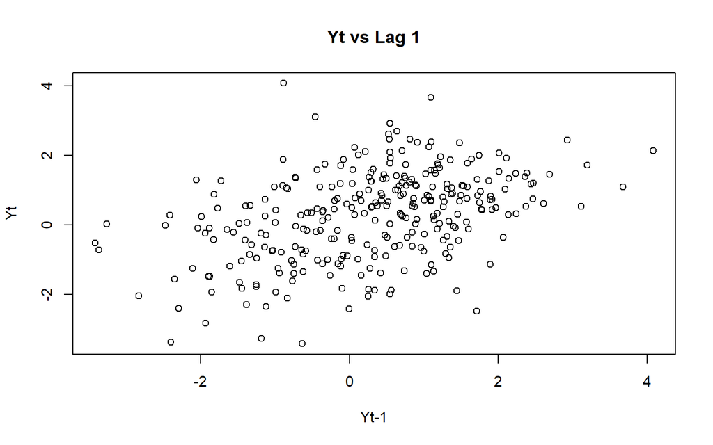

```r
plot(
  data_lag$Lag1,
  data_lag$Yt,
  main = "Yt vs Lag 1",
  xlab = "Yt-1",
  ylab = "Yt"
)
```

### Scatter Yt dengan lag 2

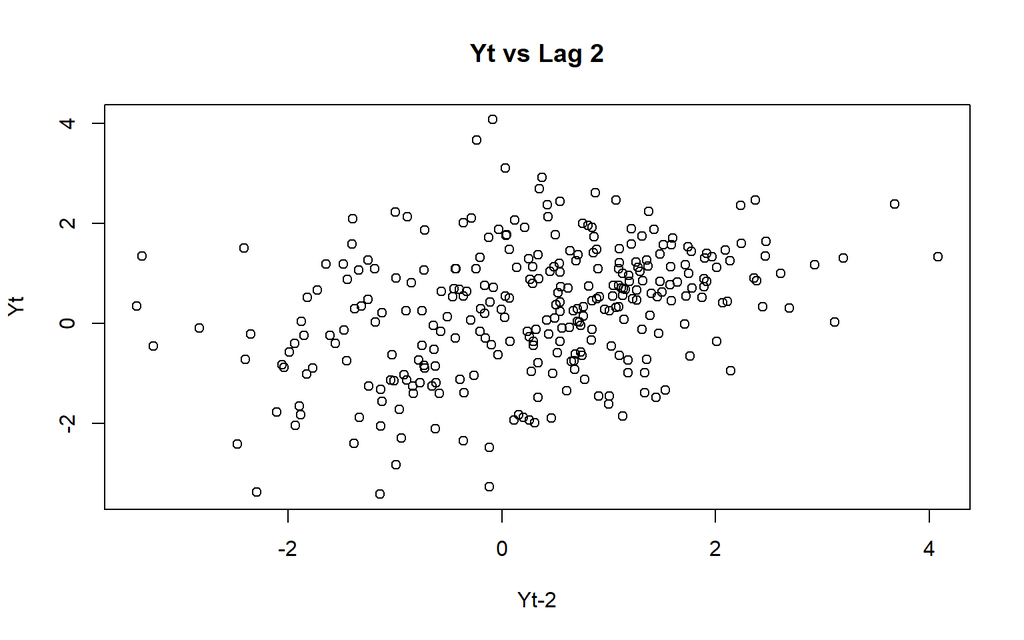

```r
plot(
  data_lag$Lag2,
  data_lag$Yt,
  main = "Yt vs Lag 2",
  xlab = "Yt-2",
  ylab = "Yt"
)
```

### Scatter Yt dengan lag 3

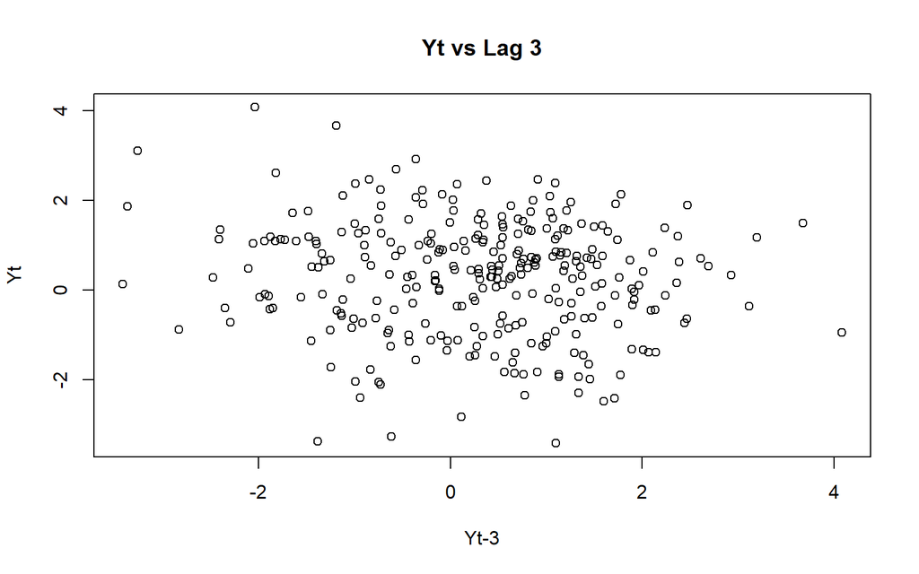

```r
plot(
  data_lag$Lag3,
  data_lag$Yt,
  main = "Yt vs Lag 3",
  xlab = "Yt-3",
  ylab = "Yt"
)
```

## Deteksi Autokorelasi Data Bangkitan

```r
acf(datama2, lag.max = 10, plot = FALSE)$acf
```

```
## , , 1
##
##              [,1]
##  [1,]  0.41343610
##  [2,]  0.33282539
##  [3,] -0.11634672
##  [4,] -0.16822212
##  [5,] -0.14216941
##  [6,] -0.08877043
##  [7,] -0.01551558
##  [8,]  0.12331788
##  [9,]  0.12720767
## [10,]  0.20172862
```

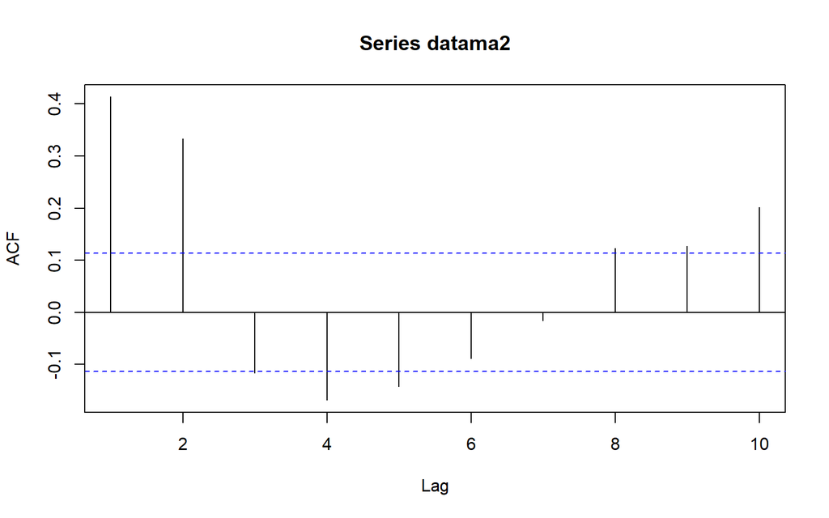

```r
acf(datama2, lag.max = 10)
```

## Deteksi Autokorelasi Teoritis

```r
theta1 <- 0.4
theta2 <- 0.6

rho1 <- (theta1 + theta1 * theta2) /
        (1 + theta1^2 + theta2^2)

rho2 <- theta2 /
        (1 + theta1^2 + theta2^2)

rho3 <- 0
rho4 <- 0
rho5 <- 0

c(rho1, rho2, rho3, rho4, rho5)
```

```
## [1] 0.4210526 0.3947368 0.0000000 0.0000000 0.0000000
```

Secara teoritis Terdapat autokorelasi signifikan pada lag 1 dan lag 2

# SOAL 2

## BANGKITKAN DATA (RA(2), n=300, chi1=0.5, chi2=0.2)

```r
dataar2 <- arima.sim(n=300, list(order=c(2,0,0), ar=c(0.5, 0.2)))
```

## Plot *Time Series*

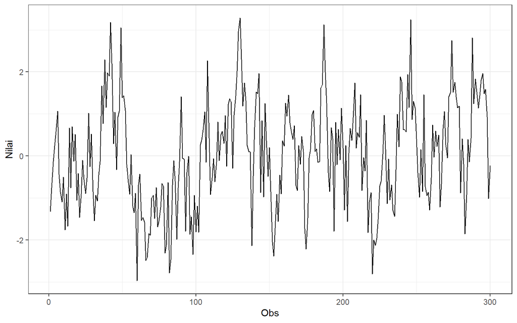

```r
plot_dataar2 <- dataar2 |> as_tsibble() |>
  ggplot(aes(x = index, y = value)) + geom_line() + theme_bw() +
  xlab("Obs") + ylab("Nilai")
plot_dataar2
```

```r
mean(dataar2)
```

```
## [1] 0.01601317
```

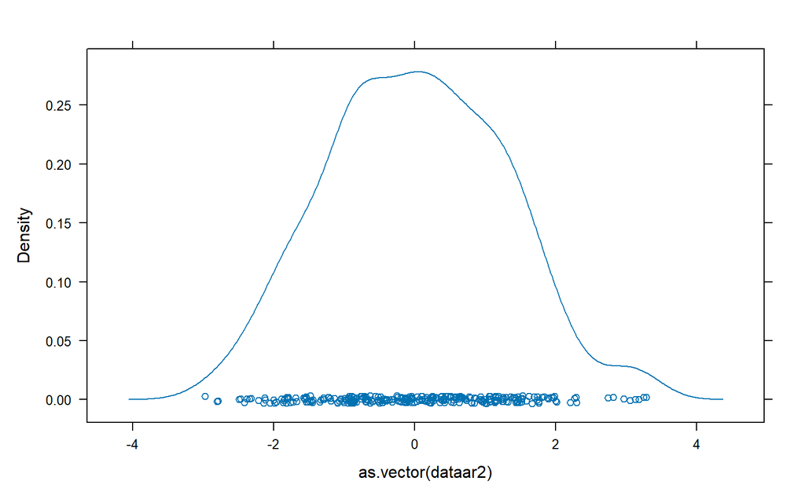

```r
lattice::densityplot(as.vector(dataar2))
```

Plot deret waktu di atas menunjukkan bahwa data stasioner dalam rataan, ditandai dengan data yang menyebar di sekitar nilai tengahnya (0) dan stasioner dalam ragam, ditandai dengan data berfluktuasi pada rentang yang relatif sama sepanjang waktu.

## Plot ACF

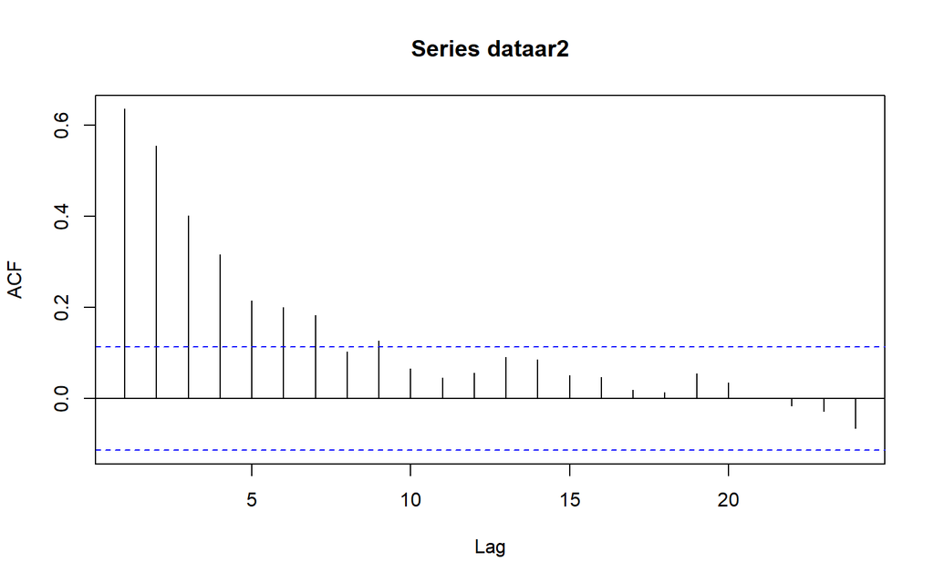

```r
acf(dataar2)
```

## Plot PACF

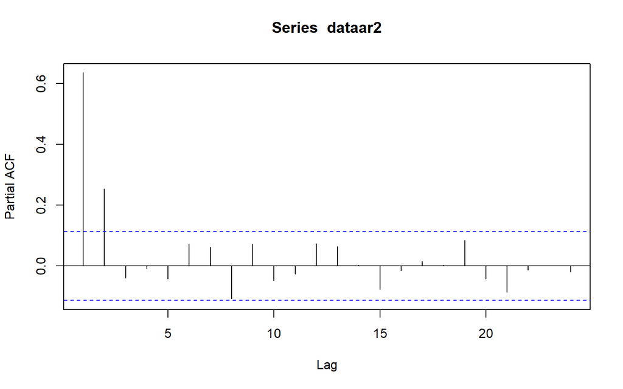

```r
pacf(dataar2)
```

## Plot EACF

```r
eacf(dataar2)
```

```
## AR/MA
##   0 1 2 3 4 5 6 7 8 9 10 11 12 13
## 0 x x x x x x x o x o o  o  o  o
## 1 x x o o o o o x x o o  o  o  o
## 2 x o o o o o o o o o o  o  o  o
## 3 x o o o o o o o o o o  o  o  o
## 4 x x o o o o o o o o o  o  o  o
## 5 x x x o o o o o o o o  o  o  o
## 6 x x x x o o o o o o o  o  o  o
## 7 x x o x o o o o o o o  o  o  o
```

## Uji ADF

Uji ADF (Augmented Dickey–Fuller) adalah uji statistik yang digunakan untuk memeriksa apakah suatu deret waktu stasioner dalam rataan.

```r
tseries::adf.test(dataar2)
```

```
##
##  Augmented Dickey-Fuller Test
##
## data:  dataar2
## Dickey-Fuller = -4.4243, Lag order = 6, p-value = 0.01
## alternative hypothesis: stationary
```

$H_0$ : Data tidak stasioner dalam rataan

$H_1$ : Data stasioner dalam rataan

Berdasarkan uji ADF tersebut, didapat *p-value* sebesar 0.01 yang lebih kecil dari taraf nyata 5% sehingga tolak $H_0$ dan menandakan bahwa data **stasioner dalam rataan**. Hal ini sesuai dengan hasil eksplorasi menggunakan plot time series dan plot ACF, dan PACF.

## Scatter Plot

```r
data_lag <- data.frame(
  Yt = dataar2,
  Lag1 = c(NA, dataar2[-length(dataar2)]),
  Lag2 = c(NA, NA, dataar2[-c(length(dataar2)-1, length(dataar2))]),
  Lag3 = c(NA, NA, NA, dataar2[-c(length(dataar2)-2, length(dataar2)-1, length(dataar2))])
)

head(data_lag)
```

```
##           Yt       Lag1       Lag2       Lag3
## 1 -1.3300139         NA         NA         NA
## 2 -0.7569513 -1.3300139         NA         NA
## 3 -0.1367415 -0.7569513 -1.3300139         NA
## 4  0.2416188 -0.1367415 -0.7569513 -1.3300139
## 5  0.5792134  0.2416188 -0.1367415 -0.7569513
## 6  1.0689358  0.5792134  0.2416188 -0.1367415
```

### Scatter Yt dengan lag 1

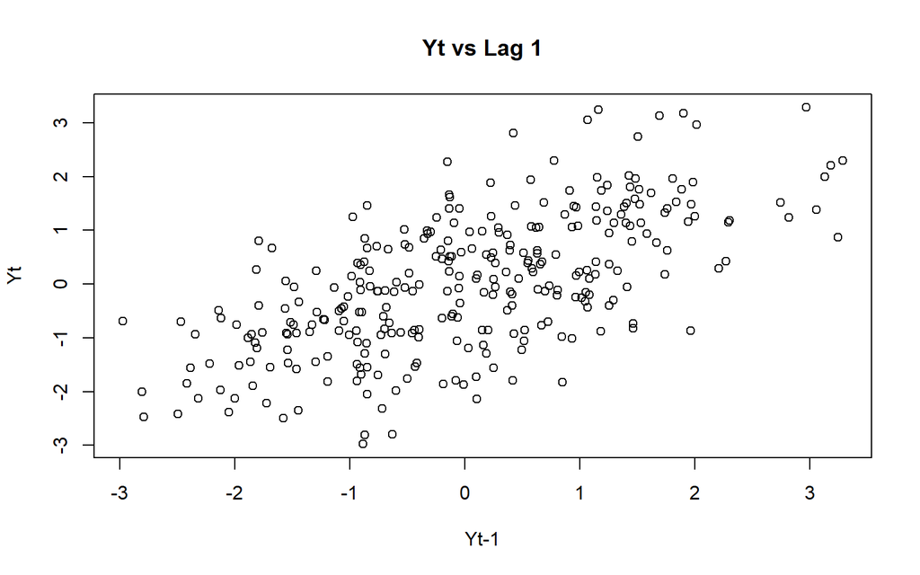

```r
plot(
  data_lag$Lag1,
  data_lag$Yt,
  main = "Yt vs Lag 1",
  xlab = "Yt-1",
  ylab = "Yt"
)
```

### Scatter Yt dengan lag 2

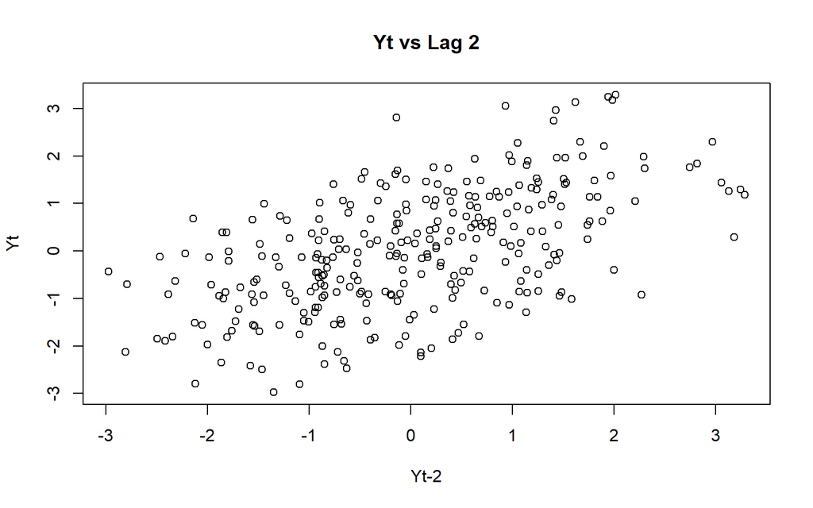

```r
plot(
  data_lag$Lag2,
  data_lag$Yt,
  main = "Yt vs Lag 2",
  xlab = "Yt-2",
  ylab = "Yt"
)
```

### Scatter Yt dengan lag 3

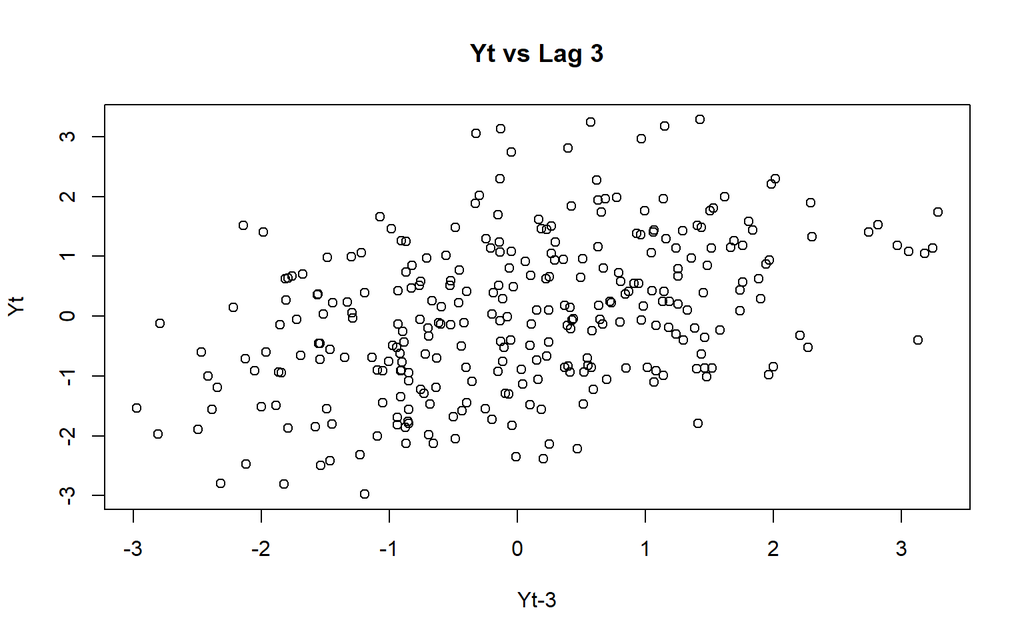

```r
plot(
  data_lag$Lag3,
  data_lag$Yt,
  main = "Yt vs Lag 3",
  xlab = "Yt-3",
  ylab = "Yt"
)
```

## Deteksi Autokorelasi Data Bangkitan

```r
acf(dataar2, lag.max = 10, plot = FALSE)$acf
```

```
## , , 1
##
##            [,1]
##  [1,] 0.6353959
##  [2,] 0.5548711
##  [3,] 0.4019077
##  [4,] 0.3160072
##  [5,] 0.2149005
##  [6,] 0.2003209
##  [7,] 0.1828973
##  [8,] 0.1026063
##  [9,] 0.1263658
## [10,] 0.0654897
```

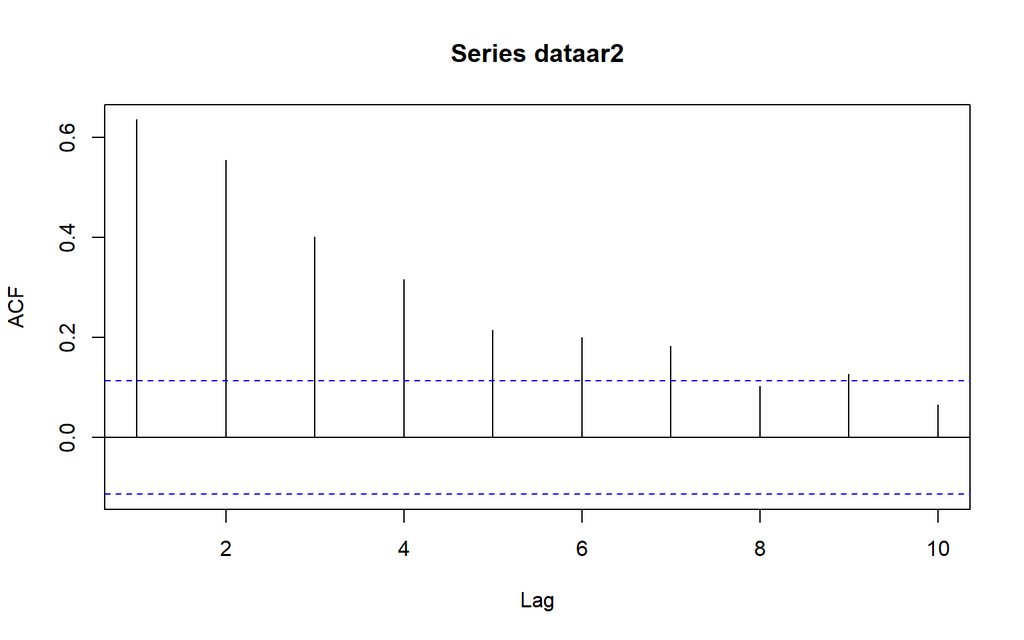

```r
acf(dataar2, lag.max = 10)
```

## Deteksi Autokorelasi Teoritis

```r
chi1 <- 0.5
chi2 <- 0.2

rho <- numeric(10)

rho[1] <- chi1 / (1 - chi2)

rho[2] <- chi1 * rho[1] + chi2

for (k in 3:10) {
  rho[k] <- chi1 * rho[k-1] + chi2 * rho[k-2]
}

rho
```

```
##  [1] 0.62500000 0.51250000 0.38125000 0.29312500 0.22281250 0.17003125
##  [7] 0.12957812 0.09879531 0.07531328 0.05741570
```

Secara teoritis Terdapat autokorelasi signifikan pada lag 1-7 sesuai dengan hasil autokorelasi dari data empirisnya.

# SOAL 3

## BANGKITKAN DATA (ARMA(2,2), n=300, chi1=0.5, chi2=0.2teta1=0.4, teta2=0.6)

```r
dataarma22 <- arima.sim(n=300, list(order=c(2,0,2), ar=c(0.5, 0.2), ma=c(0.4, 0.6)))
```

## Plot *Time Series*

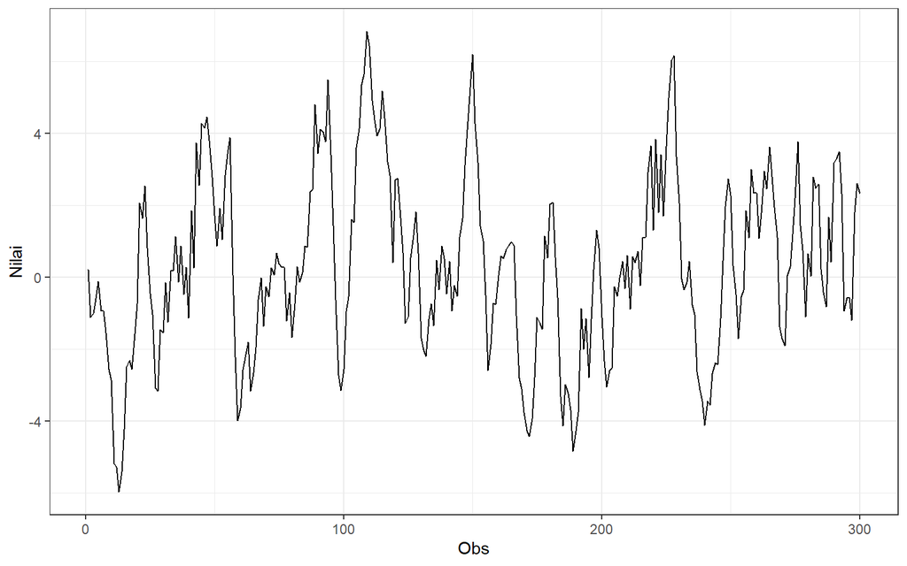

```r
plot_dataarma22 <- dataarma22 |> as_tsibble() |>
  ggplot(aes(x = index, y = value)) + geom_line() + theme_bw() +
  xlab("Obs") + ylab("Nilai")
plot_dataarma22
```

```r
mean(dataarma22)
```

```
## [1] 0.3180235
```

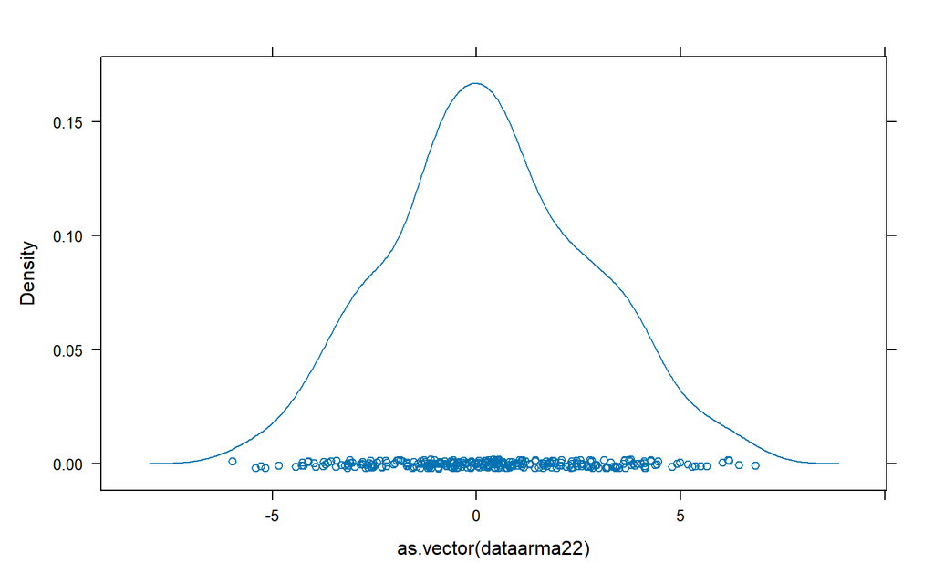

```r
lattice::densityplot(as.vector(dataarma22))
```

Plot deret waktu di atas menunjukkan bahwa data stasioner dalam rataan, ditandai dengan data yang menyebar di sekitar nilai tengahnya (0) dan stasioner dalam ragam, ditandai dengan data berfluktuasi pada rentang yang relatif sama sepanjang waktu.

## Plot ACF

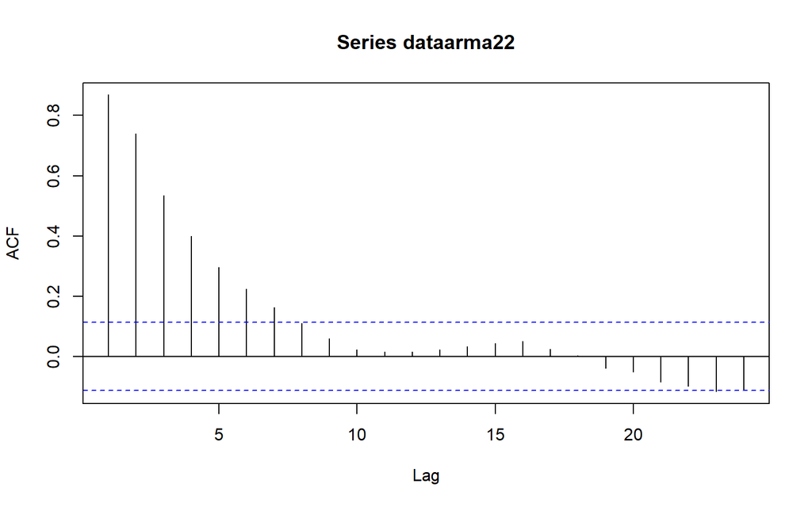

```r
acf(dataarma22)
```

Berdasarkan plot ACF, terlihat bahwa plot ACF pada data tersebut cenderung *tails off*.

## Plot PACF

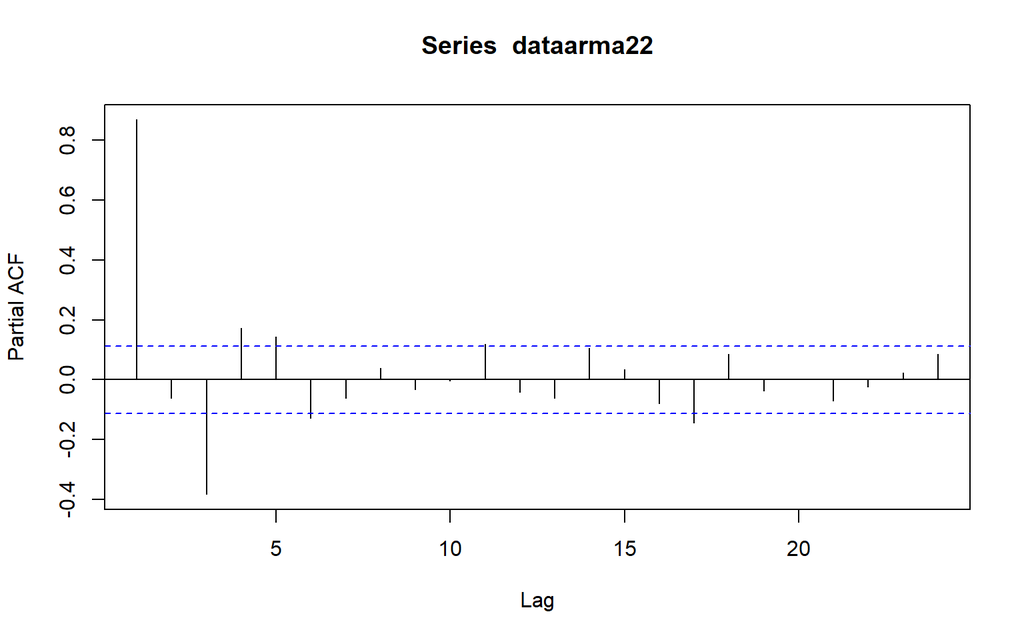

```r
pacf(dataarma22)
```

Berdasarkan plot PACF, terlihat bahwa plot PCF pada data tersebut cenderung *tails off* mengikuti pola sinus.

## Plot EACF

```r
eacf(dataarma22)
```

```
## AR/MA
##   0 1 2 3 4 5 6 7 8 9 10 11 12 13
## 0 x x x x x x x o o o o  o  o  o
## 1 o x o o o o o o o o o  o  o  o
## 2 x x o o o o o o o o o  o  o  o
## 3 x x o o o o o o o o o  o  o  o
## 4 x x x o x o o o o o o  o  o  o
## 5 x x x o x o o o o x o  o  o  o
## 6 x x x o x o o o o x o  o  o  o
## 7 x o x x o o o o o o o  o  o  o
```

## Uji ADF

Uji ADF (Augmented Dickey–Fuller) adalah uji statistik yang digunakan untuk memeriksa apakah suatu deret waktu stasioner dalam rataan.

```r
tseries::adf.test(dataarma22)
```

```
##
##  Augmented Dickey-Fuller Test
##
## data:  dataarma22
## Dickey-Fuller = -4.9558, Lag order = 6, p-value = 0.01
## alternative hypothesis: stationary
```

$H_0$ : Data tidak stasioner dalam rataan

$H_1$ : Data stasioner dalam rataan

Berdasarkan uji ADF tersebut, didapat *p-value* sebesar 0.01 yang lebih kecil dari taraf nyata 5% sehingga tolak $H_0$ dan menandakan bahwa data **stasioner dalam rataan**. Hal ini sesuai dengan hasil eksplorasi menggunakan plot time series dan plot ACF, dan PACF.

## Scatter Plot

```r
data_lag <- data.frame(
  Yt = dataarma22,
  Lag1 = c(NA, dataarma22[-length(dataarma22)]),
  Lag2 = c(NA, NA, dataarma22[-c(length(dataarma22)-1, length(dataarma22))]),
  Lag3 = c(NA, NA, NA, dataarma22[-c(length(dataarma22)-2, length(dataarma22)-1, length(dataarma22))])
)

head(data_lag)
```

```
##           Yt       Lag1       Lag2       Lag3
## 1  0.2127530         NA         NA         NA
## 2 -1.1141242  0.2127530         NA         NA
## 3 -0.9988294 -1.1141242  0.2127530         NA
## 4 -0.5921585 -0.9988294 -1.1141242  0.2127530
## 5 -0.1231625 -0.5921585 -0.9988294 -1.1141242
## 6 -0.9290726 -0.1231625 -0.5921585 -0.9988294
```

### Scatter Yt dengan lag 1

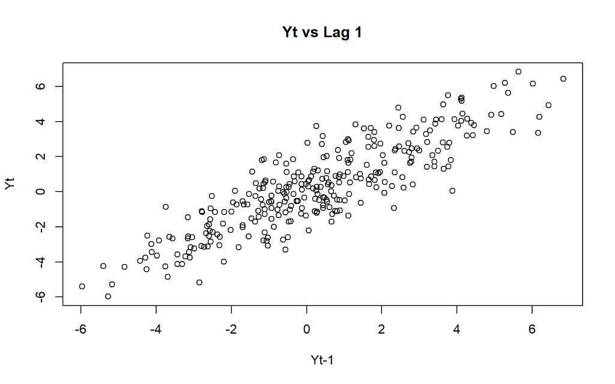

```r
plot(
  data_lag$Lag1,
  data_lag$Yt,
  main = "Yt vs Lag 1",
  xlab = "Yt-1",
  ylab = "Yt"
)
```

### Scatter Yt dengan lag 2

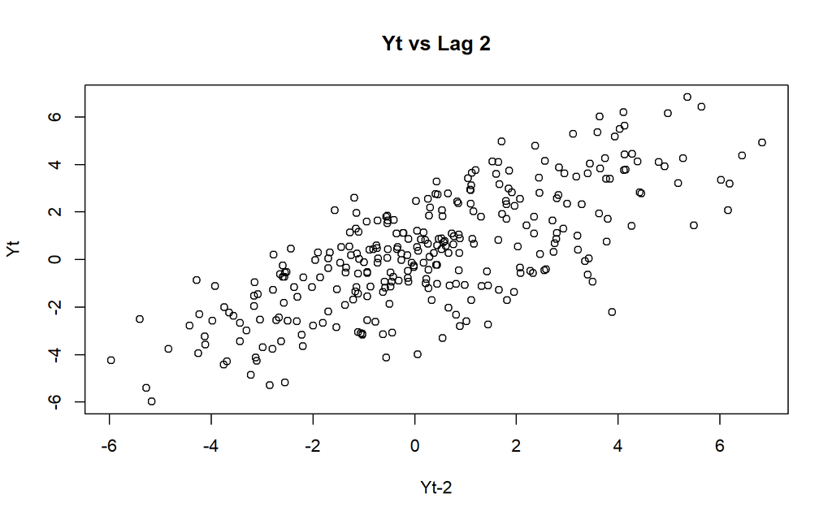

```r
plot(
  data_lag$Lag2,
  data_lag$Yt,
  main = "Yt vs Lag 2",
  xlab = "Yt-2",
  ylab = "Yt"
)
```

### Scatter Yt dengan lag 3

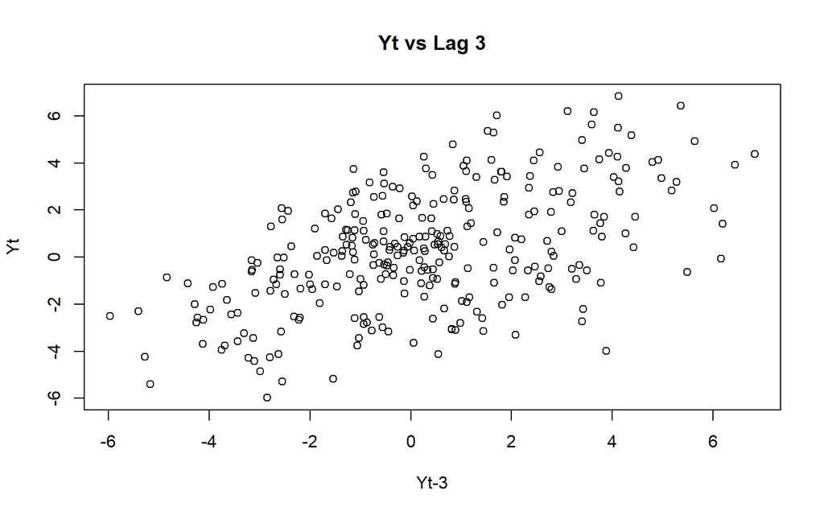

```r
plot(
  data_lag$Lag3,
  data_lag$Yt,
  main = "Yt vs Lag 3",
  xlab = "Yt-3",
  ylab = "Yt"
)
```

## Deteksi Autokorelasi Data Bangkitan

```r
acf(dataarma22, lag.max = 20, plot = FALSE)$acf
```

```
## , , 1
##
##               [,1]
##  [1,]  0.868515821
##  [2,]  0.739179621
##  [3,]  0.534349419
##  [4,]  0.399173401
##  [5,]  0.295217580
##  [6,]  0.223205424
##  [7,]  0.162986044
##  [8,]  0.109842872
##  [9,]  0.058499653
## [10,]  0.022265180
## [11,]  0.015901909
## [12,]  0.014587508
## [13,]  0.021519897
## [14,]  0.032331372
## [15,]  0.043413078
## [16,]  0.050732262
## [17,]  0.024336507
## [18,]  0.003804805
## [19,] -0.038753044
## [20,] -0.051977096
```

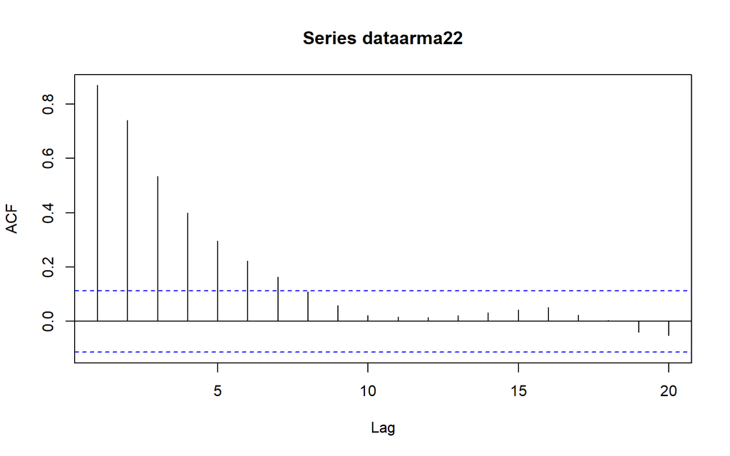

```r
acf(dataarma22, lag.max = 20)
```

## Deteksi Autokorelasi secara Teoritis

```r
acf_teoritis <- ARMAacf(
  ar = c(0.5, 0.2),
  ma = c(0.4, 0.6),
  lag.max = 20
)[-1]

acf_teoritis
```

```
##           1           2           3           4           5           6
## 0.859199319 0.749190801 0.546435264 0.423055792 0.320814949 0.245018633
##           7           8           9          10          11          12
## 0.186672306 0.142339880 0.108504401 0.082720176 0.063060968 0.048074520
##          13          14          15          16          17          18
## 0.036649453 0.027939631 0.021299706 0.016237779 0.012378831 0.009436971
##          19          20
## 0.007194252 0.005484520
```

secara toritis Terdapat autokorelasi signifikan pada lag 1-8, sedangkan pada lag selainnya tidak terdapat bukti autokorelasi yang signifikan.